## Universidad EAN

### Programación Para la Ciencia de Datos

Juan Felipe Ramírez

# Guía 3

```python
#Importar librerías
import pandas as pd
import matplotlib.pyplot as plt
import seaborn as sns
```

## Actividad 1: Filtros y Cruces

Escribir en un archivo tipo html de Jupyter bloques de código y Markdown donde se tomen las variables de una base dada y se les realice lo siguiente:

- Transformación del tipo de dato.
- Cruce de tablas.
- Filtro de variables por algún tipo de criterio.

Recomendaciones:

Orientar el acercamiento a los materiales de estudio. Asegura coherencia y suficiente detalle en la secuencia instruccional. Detalle las características del entregable. Incluir en las instrucciones cómo y cuándo utilizar los recursos de aprendizaje. Se recomienda trabajar en parejas para la revisión de las variables en la base de datos dada. Cargar la base de datos dada y empezar a revisar las variables. Determinar el tipo de cada una de las variables. Aplicar las funciones revisadas, según cada tipo de variable. Realizar la limpieza de la variable NIT proveedor. Transformar la variable del Nit. Cruzar las bases de SECOP I con la del SECOP II. Realizar un informe sobre las variables que se exploraron.

### 1.1 Lectura y limpieza del archivo SECOP I

```python
#leer archivo secop 1
secop_1 = pd.read_csv('datos_secop_I_modified.csv')
secop_1.head()
```

|  | identificador_paa | codigo_entidad | nombre_entidad | nit_entidad | anno_paa | direccion_entidad | telefono_entidad | mision_y_vision | perspectiva_estrategica | info_contacto | ppto_total | limite_menor_cuantia | limite_minima_cuantia | fecha_ultima_actualizacion | fecha_cargue | municipio_paa | departamento_paa | localidad_paa | codigo_municipio |
| --- | --- | --- | --- | --- | --- | --- | --- | --- | --- | --- | --- | --- | --- | --- | --- | --- | --- | --- | --- |
| 0 | 303062 | 28500134 | CASANARE ESE HOSPITAL DE YOPAL ! | 891855029 | 2022 | Calle 15 N 795 Manzana L via marginal de la selva | 6344699 | MisionEl Hospital Regional de la Orinoquia es ... | el Hospital Regional de la Orinoqua ESE se con... | Almacen Hospital Regional de la Orinoquia Cont... | 126898133557 | NaN | $nan | 12/31/21 | 2022-01-31T11:53:47.000 | Yopal | Casanare | PLAN UNICO | 85001 |
| 1 | 294652 | 205001279 | ANTIOQUIA INSTITUCIN EDUCATIVA DBORA ARANGO P... | 900196642 | 2022 | Calle 118 103160 | 5294058 | MISION La Institucin Educativa Dbora Arango de... | Direccionar la Institucin para el logro del ho... | Carlos Enrique Rojas Sanchez | $84026639 | 0 | 20000000 | 12/1/21 | 2022-01-26T09:43:07.000 | Medellín | Antioquia | UNICO PLAN | 5001 |
| 2 | 259436 | 286571031 | PUTUMAYO CENTRO EDUCATIVO RURAL SAUDITA PUER... | 846004233-5 | 2021 | VEREDA SAUDITA | 3208339785 | MISION El Centro Educativo Rural Saudita garan... | 0 | 3208339785 | $107700000 | 254387280 | $25438728 | 11/27/20 | 2021-01-28T02:34:58.000 | Puerto Guzmán | Putumayo | UNICO PLAN | 86571 |
| 3 | 263541 | 205001191 | ANTIOQUIA INSTITUCIN EDUCATIVA SAN CRISTBAL ... | 811017472 | 2021 | Carrera 131 No 65 07 | 4279180 | 2021 | wwwiesancristobaleduco | La Institucin Educativa San Cristbal ofrece ... | La Institucin educativa San Cristbal Lder en l... | JOSE CHARLES VELEZ BETANCURRectoriesancristoba... | 159239220 | 181705200 | 2021-01-29T04:15:31.000 | Medellín | Antioquia | UNICO PLAN | 5001 |
| 4 | 298985 | 250226019 | META CENTRO EDUCATIVO RURAL JOSE MARIA GUIOTH... | 900134298-9 | 2022 | Vda Caney Medio Km2CumaralMeta | 3013604535 | Misin | Mejoramiento de la calidad educativa en la pre... | LUIS FERNANDO ROJAS SALAZAR CC 17267322 Cargo ... | $22500000 | 280000000 | $28000000 | 12/2/21 | 2022-01-28T07:06:52.000 | Cumaral | Meta | UNICO PLAN | 50226 |

```python
#dejar nombres de columnas en mayúsculas
secop_1.columns = secop_1.columns.str.upper()
#Quitar tildes de columnas de texto y pasa a mayúsculas
for col in secop_1.columns:
    if secop_1[col].dtype == 'object':
        secop_1[col] = secop_1[col].str.upper()
        secop_1[col] = secop_1[col].str.normalize('NFKD').str.encode('ascii', errors='ignore').str.decode('utf-8')
    else:
        continue

secop_1.head()
```

|  | IDENTIFICADOR_PAA | CODIGO_ENTIDAD | NOMBRE_ENTIDAD | NIT_ENTIDAD | ANNO_PAA | DIRECCION_ENTIDAD | TELEFONO_ENTIDAD | MISION_Y_VISION | PERSPECTIVA_ESTRATEGICA | INFO_CONTACTO | PPTO_TOTAL | LIMITE_MENOR_CUANTIA | LIMITE_MINIMA_CUANTIA | FECHA_ULTIMA_ACTUALIZACION | FECHA_CARGUE | MUNICIPIO_PAA | DEPARTAMENTO_PAA | LOCALIDAD_PAA | CODIGO_MUNICIPIO |
| --- | --- | --- | --- | --- | --- | --- | --- | --- | --- | --- | --- | --- | --- | --- | --- | --- | --- | --- | --- |
| 0 | 303062 | 28500134 | CASANARE ESE HOSPITAL DE YOPAL ! | 891855029 | 2022 | CALLE 15 N 795 MANZANA L VIA MARGINAL DE LA SELVA | 6344699 | MISIONEL HOSPITAL REGIONAL DE LA ORINOQUIA ES ... | EL HOSPITAL REGIONAL DE LA ORINOQUA ESE SE CON... | ALMACEN HOSPITAL REGIONAL DE LA ORINOQUIA CONT... | 126898133557 | NaN | $NAN | 12/31/21 | 2022-01-31T11:53:47.000 | YOPAL | CASANARE | PLAN UNICO | 85001 |
| 1 | 294652 | 205001279 | ANTIOQUIA INSTITUCIN EDUCATIVA DBORA ARANGO P... | 900196642 | 2022 | CALLE 118 103160 | 5294058 | MISION LA INSTITUCIN EDUCATIVA DBORA ARANGO DE... | DIRECCIONAR LA INSTITUCIN PARA EL LOGRO DEL HO... | CARLOS ENRIQUE ROJAS SANCHEZ | $84026639 | 0 | 20000000 | 12/1/21 | 2022-01-26T09:43:07.000 | MEDELLIN | ANTIOQUIA | UNICO PLAN | 5001 |
| 2 | 259436 | 286571031 | PUTUMAYO CENTRO EDUCATIVO RURAL SAUDITA PUER... | 846004233-5 | 2021 | VEREDA SAUDITA | 3208339785 | MISION EL CENTRO EDUCATIVO RURAL SAUDITA GARAN... | 0 | 3208339785 | $107700000 | 254387280 | $25438728 | 11/27/20 | 2021-01-28T02:34:58.000 | PUERTO GUZMAN | PUTUMAYO | UNICO PLAN | 86571 |
| 3 | 263541 | 205001191 | ANTIOQUIA INSTITUCIN EDUCATIVA SAN CRISTBAL ... | 811017472 | 2021 | CARRERA 131 NO 65 07 | 4279180 | 2021 | WWWIESANCRISTOBALEDUCO | LA INSTITUCIN EDUCATIVA SAN CRISTBAL OFRECE ... | LA INSTITUCIN EDUCATIVA SAN CRISTBAL LDER EN L... | JOSE CHARLES VELEZ BETANCURRECTORIESANCRISTOBA... | 159239220 | 181705200 | 2021-01-29T04:15:31.000 | MEDELLIN | ANTIOQUIA | UNICO PLAN | 5001 |
| 4 | 298985 | 250226019 | META CENTRO EDUCATIVO RURAL JOSE MARIA GUIOTH... | 900134298-9 | 2022 | VDA CANEY MEDIO KM2CUMARALMETA | 3013604535 | MISIN | MEJORAMIENTO DE LA CALIDAD EDUCATIVA EN LA PRE... | LUIS FERNANDO ROJAS SALAZAR CC 17267322 CARGO ... | $22500000 | 280000000 | $28000000 | 12/2/21 | 2022-01-28T07:06:52.000 | CUMARAL | META | UNICO PLAN | 50226 |

```python
#truncar columna nit a 9 digitos
secop_1['NIT_ENTIDAD'] = secop_1['NIT_ENTIDAD'].str[:9]
numcols = ['NIT_ENTIDAD', 'PPTO_TOTAL', 'LIMITE_MENOR_CUANTIA', 'LIMITE_MINIMA_CUANTIA']
#quitar signo $
secop_1[numcols] = secop_1[numcols].apply(lambda x: x.str.replace('$', ''))
#Convertir columnas a numéricas
secop_1[numcols] = secop_1[numcols].apply(pd.to_numeric, errors='coerce', axis=1)
secop_1.head()
```

|  | IDENTIFICADOR_PAA | CODIGO_ENTIDAD | NOMBRE_ENTIDAD | NIT_ENTIDAD | ANNO_PAA | DIRECCION_ENTIDAD | TELEFONO_ENTIDAD | MISION_Y_VISION | PERSPECTIVA_ESTRATEGICA | INFO_CONTACTO | PPTO_TOTAL | LIMITE_MENOR_CUANTIA | LIMITE_MINIMA_CUANTIA | FECHA_ULTIMA_ACTUALIZACION | FECHA_CARGUE | MUNICIPIO_PAA | DEPARTAMENTO_PAA | LOCALIDAD_PAA | CODIGO_MUNICIPIO |
| --- | --- | --- | --- | --- | --- | --- | --- | --- | --- | --- | --- | --- | --- | --- | --- | --- | --- | --- | --- |
| 0 | 303062 | 28500134 | CASANARE ESE HOSPITAL DE YOPAL ! | 891855029.0 | 2022 | CALLE 15 N 795 MANZANA L VIA MARGINAL DE LA SELVA | 6344699 | MISIONEL HOSPITAL REGIONAL DE LA ORINOQUIA ES ... | EL HOSPITAL REGIONAL DE LA ORINOQUA ESE SE CON... | ALMACEN HOSPITAL REGIONAL DE LA ORINOQUIA CONT... | 1.268981e+11 | NaN | NaN | 12/31/21 | 2022-01-31T11:53:47.000 | YOPAL | CASANARE | PLAN UNICO | 85001 |
| 1 | 294652 | 205001279 | ANTIOQUIA INSTITUCIN EDUCATIVA DBORA ARANGO P... | 900196642.0 | 2022 | CALLE 118 103160 | 5294058 | MISION LA INSTITUCIN EDUCATIVA DBORA ARANGO DE... | DIRECCIONAR LA INSTITUCIN PARA EL LOGRO DEL HO... | CARLOS ENRIQUE ROJAS SANCHEZ | 8.402664e+07 | 0.0 | 20000000.0 | 12/1/21 | 2022-01-26T09:43:07.000 | MEDELLIN | ANTIOQUIA | UNICO PLAN | 5001 |
| 2 | 259436 | 286571031 | PUTUMAYO CENTRO EDUCATIVO RURAL SAUDITA PUER... | 846004233.0 | 2021 | VEREDA SAUDITA | 3208339785 | MISION EL CENTRO EDUCATIVO RURAL SAUDITA GARAN... | 0 | 3208339785 | 1.077000e+08 | 254387280.0 | 25438728.0 | 11/27/20 | 2021-01-28T02:34:58.000 | PUERTO GUZMAN | PUTUMAYO | UNICO PLAN | 86571 |
| 3 | 263541 | 205001191 | ANTIOQUIA INSTITUCIN EDUCATIVA SAN CRISTBAL ... | 811017472.0 | 2021 | CARRERA 131 NO 65 07 | 4279180 | 2021 | WWWIESANCRISTOBALEDUCO | LA INSTITUCIN EDUCATIVA SAN CRISTBAL OFRECE ... | NaN | NaN | 159239220.0 | 181705200 | 2021-01-29T04:15:31.000 | MEDELLIN | ANTIOQUIA | UNICO PLAN | 5001 |
| 4 | 298985 | 250226019 | META CENTRO EDUCATIVO RURAL JOSE MARIA GUIOTH... | 900134298.0 | 2022 | VDA CANEY MEDIO KM2CUMARALMETA | 3013604535 | MISIN | MEJORAMIENTO DE LA CALIDAD EDUCATIVA EN LA PRE... | LUIS FERNANDO ROJAS SALAZAR CC 17267322 CARGO ... | 2.250000e+07 | 280000000.0 | 28000000.0 | 12/2/21 | 2022-01-28T07:06:52.000 | CUMARAL | META | UNICO PLAN | 50226 |

```python
#convertir columnas de fecha al tipo de datos correcto
secop_1['FECHA_ULTIMA_ACTUALIZACION'] = pd.to_datetime(secop_1['FECHA_ULTIMA_ACTUALIZACION'], errors='coerce')
secop_1['FECHA_CARGUE'] = pd.to_datetime(secop_1['FECHA_CARGUE'], errors='coerce')
secop_1.head()
```

|  | IDENTIFICADOR_PAA | CODIGO_ENTIDAD | NOMBRE_ENTIDAD | NIT_ENTIDAD | ANNO_PAA | DIRECCION_ENTIDAD | TELEFONO_ENTIDAD | MISION_Y_VISION | PERSPECTIVA_ESTRATEGICA | INFO_CONTACTO | PPTO_TOTAL | LIMITE_MENOR_CUANTIA | LIMITE_MINIMA_CUANTIA | FECHA_ULTIMA_ACTUALIZACION | FECHA_CARGUE | MUNICIPIO_PAA | DEPARTAMENTO_PAA | LOCALIDAD_PAA | CODIGO_MUNICIPIO |
| --- | --- | --- | --- | --- | --- | --- | --- | --- | --- | --- | --- | --- | --- | --- | --- | --- | --- | --- | --- |
| 0 | 303062 | 28500134 | CASANARE ESE HOSPITAL DE YOPAL ! | 891855029.0 | 2022 | CALLE 15 N 795 MANZANA L VIA MARGINAL DE LA SELVA | 6344699 | MISIONEL HOSPITAL REGIONAL DE LA ORINOQUIA ES ... | EL HOSPITAL REGIONAL DE LA ORINOQUA ESE SE CON... | ALMACEN HOSPITAL REGIONAL DE LA ORINOQUIA CONT... | 1.268981e+11 | NaN | NaN | 2021-12-31 | 2022-01-31 11:53:47 | YOPAL | CASANARE | PLAN UNICO | 85001 |
| 1 | 294652 | 205001279 | ANTIOQUIA INSTITUCIN EDUCATIVA DBORA ARANGO P... | 900196642.0 | 2022 | CALLE 118 103160 | 5294058 | MISION LA INSTITUCIN EDUCATIVA DBORA ARANGO DE... | DIRECCIONAR LA INSTITUCIN PARA EL LOGRO DEL HO... | CARLOS ENRIQUE ROJAS SANCHEZ | 8.402664e+07 | 0.0 | 20000000.0 | 2021-12-01 | 2022-01-26 09:43:07 | MEDELLIN | ANTIOQUIA | UNICO PLAN | 5001 |
| 2 | 259436 | 286571031 | PUTUMAYO CENTRO EDUCATIVO RURAL SAUDITA PUER... | 846004233.0 | 2021 | VEREDA SAUDITA | 3208339785 | MISION EL CENTRO EDUCATIVO RURAL SAUDITA GARAN... | 0 | 3208339785 | 1.077000e+08 | 254387280.0 | 25438728.0 | 2020-11-27 | 2021-01-28 02:34:58 | PUERTO GUZMAN | PUTUMAYO | UNICO PLAN | 86571 |
| 3 | 263541 | 205001191 | ANTIOQUIA INSTITUCIN EDUCATIVA SAN CRISTBAL ... | 811017472.0 | 2021 | CARRERA 131 NO 65 07 | 4279180 | 2021 | WWWIESANCRISTOBALEDUCO | LA INSTITUCIN EDUCATIVA SAN CRISTBAL OFRECE ... | NaN | NaN | 159239220.0 | NaT | 2021-01-29 04:15:31 | MEDELLIN | ANTIOQUIA | UNICO PLAN | 5001 |
| 4 | 298985 | 250226019 | META CENTRO EDUCATIVO RURAL JOSE MARIA GUIOTH... | 900134298.0 | 2022 | VDA CANEY MEDIO KM2CUMARALMETA | 3013604535 | MISIN | MEJORAMIENTO DE LA CALIDAD EDUCATIVA EN LA PRE... | LUIS FERNANDO ROJAS SALAZAR CC 17267322 CARGO ... | 2.250000e+07 | 280000000.0 | 28000000.0 | 2021-12-02 | 2022-01-28 07:06:52 | CUMARAL | META | UNICO PLAN | 50226 |

### 1.2 Lectura y limpieza del archivo SECOP II

```python
#leer archivo secop 2
secop_2 = pd.read_csv('datos_secov_II_modified.csv', sep=';', encoding = "latin-1")
secop_2.head()
```

|  | identificador_unico | id_plan_anual_de_adquisiciones | anno | nit_entidad | nombre_entidad | mision_vision | perspectiva_estrategica | nombre_contacto | telefono_contacto | correo_contacto | ... | presupuesto_menor_cuantia | presupuesto_minima_cuantia | fecha_de_publicacion | fecha_de_creacion | fecha_de_ultima_modificacion | version | identificador_requerimiento_compra | estado | departamento_paa | municipio_paa |
| --- | --- | --- | --- | --- | --- | --- | --- | --- | --- | --- | --- | --- | --- | --- | --- | --- | --- | --- | --- | --- | --- |
| 0 | CO1.APP.2041264 | MarketplaceCO1538159 | 2024 | 721520377 | INSTITUCION EDUCATIVA AGROPECUARIA MAXIMO GOMEZ | MISION 2023 2026 La Institucin Educativa Agrop... | Ser una institucin destacada por sus estrategi... | MARIA EUGENIA LEDESMA LLANTEN | 3104661182 | mariaeugenia.maestra@gmail.com | ... | $26000000.0 | $2600000.0 | 2024-07-31 03:47:42.6041815 | 2024-08-23 07:11:00.0000000 | 2024-08-22 20:32:26.391947400 | 2 | CO1.PPI.33807381 | Borrador | Cauca | Cajibío |
| 1 | CO1.APP.2041602 | MarketplaceCO1538240 | 2024 | 718938582 | INSTITUCION EDUCATIVA MUNICIPAL EL SOCORRO | MISION Brindar una formacin acadmica que forme... | El proceso de formacin de los educandos debe e... | RAFAEL BASTIDAS SANCHEZ | 3136820189 | rafabastidas@hotmail.com | ... | $845000000.0 | $84500000.0 | 2024-01-31 16:19:08.5384812 | 2024-08-23 07:11:00.0000000 | 2024-08-22 22:00:52.607658300 | 13 | CO1.PPI.33809817 | No especificado | Nariño | Pasto |
| 2 | CO1.APP.2041198 | MarketplaceCO1538184 | 2024 | 703036004 | MUNICIPIO LA DORADA | La administracin municipal regir los destinos ... | La Dorada ser un municipio competitivo y soste... | JULIAN DAVID OLIVEROS SERRANO | 8572013 | compras@ladorada-caldas.gov.co | ... | $364000000.0 | $36400000.0 | 2024-01-17 20:54:03.3001599 | 2024-08-23 07:11:00.0000000 | 2024-08-22 21:03:45.672865800 | 28 | CO1.PPI.33808340 | Borrador | Caldas | La Dorada |
| 3 | CO1.APP.2041074 | MarketplaceCO1538121 | 2024 | 723119863 | COOAGUAS DE PUEBLO NUEVO E.S.P. | MISION LA ADMINISTRACION PBLICA COOPERATIVA EM... | POLITICA DE CALIDAD Somos un organismo pblico ... | CARLOS FERNANDO GERMAN CALAO | 3127695263 | carlosgcalao@outlook.com | ... | 174000000.0 | 116000000.0 | 2024-02-01 02:01:48.3772533 | 2024-08-23 07:11:00.0000000 | 2024-08-22 19:47:30.908245300 | 2 | CO1.PPI.33805980 | Borrador | Córdoba | Pueblo Nuevo |
| 4 | CO1.APP.2041030 | MarketplaceCO1415172 | 2024 | 705153815 | MUNICIPIO DE LA PLATA | Gestionar servir a la comunidad promover el bi... | A travs de la implementacin del presente Plan ... | CRISTINA HOLGUIN GRISALES | 3223001245 | almacen@laplata-huila.gov.co | ... | $364000000.0 | $36400000.0 | 2024-01-10 15:55:50.6223556 | 2024-08-23 07:11:00.0000000 | 2024-08-22 15:48:03.701324800 | 148 | CO1.PPI.33799556 | Publicado | Huila | La Plata |

5 rows × 21 columns

```python
#dejar nombres de columnas en mayúsculas
secop_2.columns = secop_2.columns.str.upper()
#Quitar tildes de columnas de texto y pasa a mayúsculas
for col in secop_2.columns:
    if secop_2[col].dtype == 'object':
        secop_2[col] = secop_2[col].str.upper()
        secop_2[col] = secop_2[col].str.normalize('NFKD').str.encode('ascii', errors='ignore').str.decode('utf-8')
    else:
        continue

secop_1.head()
```

|  | IDENTIFICADOR_PAA | CODIGO_ENTIDAD | NOMBRE_ENTIDAD | NIT_ENTIDAD | ANNO_PAA | DIRECCION_ENTIDAD | TELEFONO_ENTIDAD | MISION_Y_VISION | PERSPECTIVA_ESTRATEGICA | INFO_CONTACTO | PPTO_TOTAL | LIMITE_MENOR_CUANTIA | LIMITE_MINIMA_CUANTIA | FECHA_ULTIMA_ACTUALIZACION | FECHA_CARGUE | MUNICIPIO_PAA | DEPARTAMENTO_PAA | LOCALIDAD_PAA | CODIGO_MUNICIPIO |
| --- | --- | --- | --- | --- | --- | --- | --- | --- | --- | --- | --- | --- | --- | --- | --- | --- | --- | --- | --- |
| 0 | 303062 | 28500134 | CASANARE ESE HOSPITAL DE YOPAL ! | 891855029.0 | 2022 | CALLE 15 N 795 MANZANA L VIA MARGINAL DE LA SELVA | 6344699 | MISIONEL HOSPITAL REGIONAL DE LA ORINOQUIA ES ... | EL HOSPITAL REGIONAL DE LA ORINOQUA ESE SE CON... | ALMACEN HOSPITAL REGIONAL DE LA ORINOQUIA CONT... | 1.268981e+11 | NaN | NaN | 2021-12-31 | 2022-01-31 11:53:47 | YOPAL | CASANARE | PLAN UNICO | 85001 |
| 1 | 294652 | 205001279 | ANTIOQUIA INSTITUCIN EDUCATIVA DBORA ARANGO P... | 900196642.0 | 2022 | CALLE 118 103160 | 5294058 | MISION LA INSTITUCIN EDUCATIVA DBORA ARANGO DE... | DIRECCIONAR LA INSTITUCIN PARA EL LOGRO DEL HO... | CARLOS ENRIQUE ROJAS SANCHEZ | 8.402664e+07 | 0.0 | 20000000.0 | 2021-12-01 | 2022-01-26 09:43:07 | MEDELLIN | ANTIOQUIA | UNICO PLAN | 5001 |
| 2 | 259436 | 286571031 | PUTUMAYO CENTRO EDUCATIVO RURAL SAUDITA PUER... | 846004233.0 | 2021 | VEREDA SAUDITA | 3208339785 | MISION EL CENTRO EDUCATIVO RURAL SAUDITA GARAN... | 0 | 3208339785 | 1.077000e+08 | 254387280.0 | 25438728.0 | 2020-11-27 | 2021-01-28 02:34:58 | PUERTO GUZMAN | PUTUMAYO | UNICO PLAN | 86571 |
| 3 | 263541 | 205001191 | ANTIOQUIA INSTITUCIN EDUCATIVA SAN CRISTBAL ... | 811017472.0 | 2021 | CARRERA 131 NO 65 07 | 4279180 | 2021 | WWWIESANCRISTOBALEDUCO | LA INSTITUCIN EDUCATIVA SAN CRISTBAL OFRECE ... | NaN | NaN | 159239220.0 | NaT | 2021-01-29 04:15:31 | MEDELLIN | ANTIOQUIA | UNICO PLAN | 5001 |
| 4 | 298985 | 250226019 | META CENTRO EDUCATIVO RURAL JOSE MARIA GUIOTH... | 900134298.0 | 2022 | VDA CANEY MEDIO KM2CUMARALMETA | 3013604535 | MISIN | MEJORAMIENTO DE LA CALIDAD EDUCATIVA EN LA PRE... | LUIS FERNANDO ROJAS SALAZAR CC 17267322 CARGO ... | 2.250000e+07 | 280000000.0 | 28000000.0 | 2021-12-02 | 2022-01-28 07:06:52 | CUMARAL | META | UNICO PLAN | 50226 |

```python
#truncar columna nit a 9 digitos y convertir columnas a númericas
secop_2['NIT_ENTIDAD'] = secop_2['NIT_ENTIDAD'].str[:9]
numcols_2 = ['NIT_ENTIDAD', 'VALOR_PRESUPUESTO_GENERAL', 'PRESUPUESTO_MENOR_CUANTIA', 'PRESUPUESTO_MINIMA_CUANTIA']
#quitar signo $
secop_2[numcols_2] = secop_2[numcols_2].apply(lambda x: x.str.replace('$', ''))
#Convertir columnas a numéricas
secop_2[numcols_2] = secop_2[numcols_2].apply(pd.to_numeric, errors='coerce', axis=1)
secop_2.head()
```

|  | IDENTIFICADOR_UNICO | ID_PLAN_ANUAL_DE_ADQUISICIONES | ANNO | NIT_ENTIDAD | NOMBRE_ENTIDAD | MISION_VISION | PERSPECTIVA_ESTRATEGICA | NOMBRE_CONTACTO | TELEFONO_CONTACTO | CORREO_CONTACTO | ... | PRESUPUESTO_MENOR_CUANTIA | PRESUPUESTO_MINIMA_CUANTIA | FECHA_DE_PUBLICACION | FECHA_DE_CREACION | FECHA_DE_ULTIMA_MODIFICACION | VERSION | IDENTIFICADOR_REQUERIMIENTO_COMPRA | ESTADO | DEPARTAMENTO_PAA | MUNICIPIO_PAA |
| --- | --- | --- | --- | --- | --- | --- | --- | --- | --- | --- | --- | --- | --- | --- | --- | --- | --- | --- | --- | --- | --- |
| 0 | CO1.APP.2041264 | MARKETPLACECO1538159 | 2024 | 721520377.0 | INSTITUCION EDUCATIVA AGROPECUARIA MAXIMO GOMEZ | MISION 2023 2026 LA INSTITUCIN EDUCATIVA AGROP... | SER UNA INSTITUCIN DESTACADA POR SUS ESTRATEGI... | MARIA EUGENIA LEDESMA LLANTEN | 3104661182 | MARIAEUGENIA.MAESTRA@GMAIL.COM | ... | 26000000.0 | 2600000.0 | 2024-07-31 03:47:42.6041815 | 2024-08-23 07:11:00.0000000 | 2024-08-22 20:32:26.391947400 | 2 | CO1.PPI.33807381 | BORRADOR | CAUCA | CAJIBIO |
| 1 | CO1.APP.2041602 | MARKETPLACECO1538240 | 2024 | 718938582.0 | INSTITUCION EDUCATIVA MUNICIPAL EL SOCORRO | MISION BRINDAR UNA FORMACIN ACADMICA QUE FORME... | EL PROCESO DE FORMACIN DE LOS EDUCANDOS DEBE E... | RAFAEL BASTIDAS SANCHEZ | 3136820189 | RAFABASTIDAS@HOTMAIL.COM | ... | 845000000.0 | 84500000.0 | 2024-01-31 16:19:08.5384812 | 2024-08-23 07:11:00.0000000 | 2024-08-22 22:00:52.607658300 | 13 | CO1.PPI.33809817 | NO ESPECIFICADO | NARINO | PASTO |
| 2 | CO1.APP.2041198 | MARKETPLACECO1538184 | 2024 | 703036004.0 | MUNICIPIO LA DORADA | LA ADMINISTRACIN MUNICIPAL REGIR LOS DESTINOS ... | LA DORADA SER UN MUNICIPIO COMPETITIVO Y SOSTE... | JULIAN DAVID OLIVEROS SERRANO | 8572013 | COMPRAS@LADORADA-CALDAS.GOV.CO | ... | 364000000.0 | 36400000.0 | 2024-01-17 20:54:03.3001599 | 2024-08-23 07:11:00.0000000 | 2024-08-22 21:03:45.672865800 | 28 | CO1.PPI.33808340 | BORRADOR | CALDAS | LA DORADA |
| 3 | CO1.APP.2041074 | MARKETPLACECO1538121 | 2024 | 723119863.0 | COOAGUAS DE PUEBLO NUEVO E.S.P. | MISION LA ADMINISTRACION PBLICA COOPERATIVA EM... | POLITICA DE CALIDAD SOMOS UN ORGANISMO PBLICO ... | CARLOS FERNANDO GERMAN CALAO | 3127695263 | CARLOSGCALAO@OUTLOOK.COM | ... | 174000000.0 | 116000000.0 | 2024-02-01 02:01:48.3772533 | 2024-08-23 07:11:00.0000000 | 2024-08-22 19:47:30.908245300 | 2 | CO1.PPI.33805980 | BORRADOR | CORDOBA | PUEBLO NUEVO |
| 4 | CO1.APP.2041030 | MARKETPLACECO1415172 | 2024 | 705153815.0 | MUNICIPIO DE LA PLATA | GESTIONAR SERVIR A LA COMUNIDAD PROMOVER EL BI... | A TRAVS DE LA IMPLEMENTACIN DEL PRESENTE PLAN ... | CRISTINA HOLGUIN GRISALES | 3223001245 | ALMACEN@LAPLATA-HUILA.GOV.CO | ... | 364000000.0 | 36400000.0 | 2024-01-10 15:55:50.6223556 | 2024-08-23 07:11:00.0000000 | 2024-08-22 15:48:03.701324800 | 148 | CO1.PPI.33799556 | PUBLICADO | HUILA | LA PLATA |

5 rows × 21 columns

```python
#convertir columnas de fecha al tipo de datos correcto
secop_2['FECHA_DE_PUBLICACION'] = pd.to_datetime(secop_2['FECHA_DE_PUBLICACION'], errors='coerce')
secop_2['FECHA_DE_CREACION'] = pd.to_datetime(secop_2['FECHA_DE_CREACION'], errors='coerce')
secop_2['FECHA_DE_ULTIMA_MODIFICACION'] = pd.to_datetime(secop_2['FECHA_DE_ULTIMA_MODIFICACION'], errors='coerce')
secop_2.head()
```

|  | IDENTIFICADOR_UNICO | ID_PLAN_ANUAL_DE_ADQUISICIONES | ANNO | NIT_ENTIDAD | NOMBRE_ENTIDAD | MISION_VISION | PERSPECTIVA_ESTRATEGICA | NOMBRE_CONTACTO | TELEFONO_CONTACTO | CORREO_CONTACTO | ... | PRESUPUESTO_MENOR_CUANTIA | PRESUPUESTO_MINIMA_CUANTIA | FECHA_DE_PUBLICACION | FECHA_DE_CREACION | FECHA_DE_ULTIMA_MODIFICACION | VERSION | IDENTIFICADOR_REQUERIMIENTO_COMPRA | ESTADO | DEPARTAMENTO_PAA | MUNICIPIO_PAA |
| --- | --- | --- | --- | --- | --- | --- | --- | --- | --- | --- | --- | --- | --- | --- | --- | --- | --- | --- | --- | --- | --- |
| 0 | CO1.APP.2041264 | MARKETPLACECO1538159 | 2024 | 721520377.0 | INSTITUCION EDUCATIVA AGROPECUARIA MAXIMO GOMEZ | MISION 2023 2026 LA INSTITUCIN EDUCATIVA AGROP... | SER UNA INSTITUCIN DESTACADA POR SUS ESTRATEGI... | MARIA EUGENIA LEDESMA LLANTEN | 3104661182 | MARIAEUGENIA.MAESTRA@GMAIL.COM | ... | 26000000.0 | 2600000.0 | 2024-07-31 03:47:42.604181500 | 2024-08-23 07:11:00 | 2024-08-22 20:32:26.391947400 | 2 | CO1.PPI.33807381 | BORRADOR | CAUCA | CAJIBIO |
| 1 | CO1.APP.2041602 | MARKETPLACECO1538240 | 2024 | 718938582.0 | INSTITUCION EDUCATIVA MUNICIPAL EL SOCORRO | MISION BRINDAR UNA FORMACIN ACADMICA QUE FORME... | EL PROCESO DE FORMACIN DE LOS EDUCANDOS DEBE E... | RAFAEL BASTIDAS SANCHEZ | 3136820189 | RAFABASTIDAS@HOTMAIL.COM | ... | 845000000.0 | 84500000.0 | 2024-01-31 16:19:08.538481200 | 2024-08-23 07:11:00 | 2024-08-22 22:00:52.607658300 | 13 | CO1.PPI.33809817 | NO ESPECIFICADO | NARINO | PASTO |
| 2 | CO1.APP.2041198 | MARKETPLACECO1538184 | 2024 | 703036004.0 | MUNICIPIO LA DORADA | LA ADMINISTRACIN MUNICIPAL REGIR LOS DESTINOS ... | LA DORADA SER UN MUNICIPIO COMPETITIVO Y SOSTE... | JULIAN DAVID OLIVEROS SERRANO | 8572013 | COMPRAS@LADORADA-CALDAS.GOV.CO | ... | 364000000.0 | 36400000.0 | 2024-01-17 20:54:03.300159900 | 2024-08-23 07:11:00 | 2024-08-22 21:03:45.672865800 | 28 | CO1.PPI.33808340 | BORRADOR | CALDAS | LA DORADA |
| 3 | CO1.APP.2041074 | MARKETPLACECO1538121 | 2024 | 723119863.0 | COOAGUAS DE PUEBLO NUEVO E.S.P. | MISION LA ADMINISTRACION PBLICA COOPERATIVA EM... | POLITICA DE CALIDAD SOMOS UN ORGANISMO PBLICO ... | CARLOS FERNANDO GERMAN CALAO | 3127695263 | CARLOSGCALAO@OUTLOOK.COM | ... | 174000000.0 | 116000000.0 | 2024-02-01 02:01:48.377253300 | 2024-08-23 07:11:00 | 2024-08-22 19:47:30.908245300 | 2 | CO1.PPI.33805980 | BORRADOR | CORDOBA | PUEBLO NUEVO |
| 4 | CO1.APP.2041030 | MARKETPLACECO1415172 | 2024 | 705153815.0 | MUNICIPIO DE LA PLATA | GESTIONAR SERVIR A LA COMUNIDAD PROMOVER EL BI... | A TRAVS DE LA IMPLEMENTACIN DEL PRESENTE PLAN ... | CRISTINA HOLGUIN GRISALES | 3223001245 | ALMACEN@LAPLATA-HUILA.GOV.CO | ... | 364000000.0 | 36400000.0 | 2024-01-10 15:55:50.622355600 | 2024-08-23 07:11:00 | 2024-08-22 15:48:03.701324800 | 148 | CO1.PPI.33799556 | PUBLICADO | HUILA | LA PLATA |

5 rows × 21 columns

### 1.3 Unión de los 2 DataFrames

```python
#exploración de los años de registro para secop 1
secop_1.ANNO_PAA.value_counts()
```

```
ANNO_PAA
2022    418
2021    417
2023    143
2020     22
Name: count, dtype: int64
```

```python
#exploración de los años de registro para secop 2
secop_2.ANNO.value_counts()
```

```
ANNO
2024    585
2023    168
2022    120
2021     31
2020     27
2019     26
2018     22
2017     14
2016      6
2025      1
Name: count, dtype: int64
```

Al notar que los datos de Secop 2 abarcan un periodo de tiempo mayor que Secop 1 pero que ambos archivos tienen información similar, parece que el mejor curso de acción para juntar ambos dataframes es una unión vertical conservando únicamente las columnas que ambos dataframes tienen en común.

```python
#exploración de las columnas de secop 1 y secop 2
display(secop_1.columns)
secop_2.columns
```

```
Index(['IDENTIFICADOR_PAA', 'CODIGO_ENTIDAD', 'NOMBRE_ENTIDAD', 'NIT_ENTIDAD',
       'ANNO_PAA', 'DIRECCION_ENTIDAD', 'TELEFONO_ENTIDAD', 'MISION_Y_VISION',
       'PERSPECTIVA_ESTRATEGICA', 'INFO_CONTACTO', 'PPTO_TOTAL',
       'LIMITE_MENOR_CUANTIA', 'LIMITE_MINIMA_CUANTIA',
       'FECHA_ULTIMA_ACTUALIZACION', 'FECHA_CARGUE', 'MUNICIPIO_PAA',
       'DEPARTAMENTO_PAA', 'LOCALIDAD_PAA', 'CODIGO_MUNICIPIO'],
      dtype='object')
```

```
Index(['IDENTIFICADOR_UNICO', 'ID_PLAN_ANUAL_DE_ADQUISICIONES', 'ANNO',
       'NIT_ENTIDAD', 'NOMBRE_ENTIDAD', 'MISION_VISION',
       'PERSPECTIVA_ESTRATEGICA', 'NOMBRE_CONTACTO', 'TELEFONO_CONTACTO',
       'CORREO_CONTACTO', 'VALOR_PRESUPUESTO_GENERAL',
       'PRESUPUESTO_MENOR_CUANTIA', 'PRESUPUESTO_MINIMA_CUANTIA',
       'FECHA_DE_PUBLICACION', 'FECHA_DE_CREACION',
       'FECHA_DE_ULTIMA_MODIFICACION', 'VERSION',
       'IDENTIFICADOR_REQUERIMIENTO_COMPRA', 'ESTADO', 'DEPARTAMENTO_PAA',
       'MUNICIPIO_PAA'],
      dtype='object')
```

```python
#definir nuevos dataframes con el orden igual de variables en común para realizar un análisis
sec_1=secop_1[['NIT_ENTIDAD','NOMBRE_ENTIDAD','ANNO_PAA', 'MISION_Y_VISION','PERSPECTIVA_ESTRATEGICA',
    'PPTO_TOTAL','LIMITE_MENOR_CUANTIA','LIMITE_MINIMA_CUANTIA','FECHA_CARGUE',
    'FECHA_ULTIMA_ACTUALIZACION','DEPARTAMENTO_PAA','MUNICIPIO_PAA']]
sec_2=secop_2[['NIT_ENTIDAD','NOMBRE_ENTIDAD','ANNO', 'MISION_VISION','PERSPECTIVA_ESTRATEGICA',
    'VALOR_PRESUPUESTO_GENERAL','PRESUPUESTO_MENOR_CUANTIA','PRESUPUESTO_MINIMA_CUANTIA','FECHA_DE_PUBLICACION',
    'FECHA_DE_ULTIMA_MODIFICACION','DEPARTAMENTO_PAA','MUNICIPIO_PAA']]
#cambio de nombres de columnas de secop 2 para que coincidan con secop 1
sec_2.rename(columns={'ANNO':'ANNO_PAA', 'MISION_VISION':'MISION_Y_VISION',
    'VALOR_PRESUPUESTO_GENERAL':'PPTO_TOTAL','PRESUPUESTO_MENOR_CUANTIA':'LIMITE_MENOR_CUANTIA',
    'PRESUPUESTO_MINIMA_CUANTIA':'LIMITE_MINIMA_CUANTIA','FECHA_DE_PUBLICACION':'FECHA_CARGUE',
    'FECHA_DE_ULTIMA_MODIFICACION':'FECHA_ULTIMA_ACTUALIZACION','DEPARTAMENTO':'DEPARTAMENTO_PAA',
    'MUNICIPIO':'MUNICIPIO_PAA'}, inplace=True)

#unir dataframes
secop = pd.concat([sec_1, sec_2], axis=0)
#convertir columna de año a tipo categorica
secop['ANNO_PAA'] = secop['ANNO_PAA'].astype('category')
secop.head()
```

|  | NIT_ENTIDAD | NOMBRE_ENTIDAD | ANNO_PAA | MISION_Y_VISION | PERSPECTIVA_ESTRATEGICA | PPTO_TOTAL | LIMITE_MENOR_CUANTIA | LIMITE_MINIMA_CUANTIA | FECHA_CARGUE | FECHA_ULTIMA_ACTUALIZACION | DEPARTAMENTO_PAA | MUNICIPIO_PAA |
| --- | --- | --- | --- | --- | --- | --- | --- | --- | --- | --- | --- | --- |
| 0 | 891855029.0 | CASANARE ESE HOSPITAL DE YOPAL ! | 2022 | MISIONEL HOSPITAL REGIONAL DE LA ORINOQUIA ES ... | EL HOSPITAL REGIONAL DE LA ORINOQUA ESE SE CON... | 1.268981e+11 | NaN | NaN | 2022-01-31 11:53:47 | 2021-12-31 | CASANARE | YOPAL |
| 1 | 900196642.0 | ANTIOQUIA INSTITUCIN EDUCATIVA DBORA ARANGO P... | 2022 | MISION LA INSTITUCIN EDUCATIVA DBORA ARANGO DE... | DIRECCIONAR LA INSTITUCIN PARA EL LOGRO DEL HO... | 8.402664e+07 | 0.0 | 20000000.0 | 2022-01-26 09:43:07 | 2021-12-01 | ANTIOQUIA | MEDELLIN |
| 2 | 846004233.0 | PUTUMAYO CENTRO EDUCATIVO RURAL SAUDITA PUER... | 2021 | MISION EL CENTRO EDUCATIVO RURAL SAUDITA GARAN... | 0 | 1.077000e+08 | 254387280.0 | 25438728.0 | 2021-01-28 02:34:58 | 2020-11-27 | PUTUMAYO | PUERTO GUZMAN |
| 3 | 811017472.0 | ANTIOQUIA INSTITUCIN EDUCATIVA SAN CRISTBAL ... | 2021 | 2021 | WWWIESANCRISTOBALEDUCO | NaN | NaN | 159239220.0 | 2021-01-29 04:15:31 | NaT | ANTIOQUIA | MEDELLIN |
| 4 | 900134298.0 | META CENTRO EDUCATIVO RURAL JOSE MARIA GUIOTH... | 2022 | MISIN | MEJORAMIENTO DE LA CALIDAD EDUCATIVA EN LA PRE... | 2.250000e+07 | 280000000.0 | 28000000.0 | 2022-01-28 07:06:52 | 2021-12-02 | META | CUMARAL |

## Actividad 2: Visualización

Producto Escribir en un archivo tipo html de Jupyter bloques de código y Markdown donde se tomen las variables de una base dada y se les realice lo siguiente:

Identificación y alguna transformación del tipo de dato. Filtro de variables por algún tipo de criterio. Utilizar al menos 2 tipos de gráficos para variables seleccionadas. Enviar el archivo en formato HTML al tutor en la plataforma.

Instrucciones específicas para desarrollar el producto

Recomendaciones:

Se recomienda trabajar en parejas para la revisión de las variables en la base de datos dada. Cargar la base de datos dada y empezar a revisar las variables. Determinar el tipo de cada una de las variables. Aplicar las funciones revisadas, para la transformación del dato y cambiar su tipo. Realizar filtros de tablas requeridos. Realizar las gráficas de algunas variables seleccionadas.

```python
secop.head()
```

|  | NIT_ENTIDAD | NOMBRE_ENTIDAD | ANNO_PAA | MISION_Y_VISION | PERSPECTIVA_ESTRATEGICA | PPTO_TOTAL | LIMITE_MENOR_CUANTIA | LIMITE_MINIMA_CUANTIA | FECHA_CARGUE | FECHA_ULTIMA_ACTUALIZACION | DEPARTAMENTO_PAA | MUNICIPIO_PAA |
| --- | --- | --- | --- | --- | --- | --- | --- | --- | --- | --- | --- | --- |
| 0 | 891855029.0 | CASANARE ESE HOSPITAL DE YOPAL ! | 2022 | MISIONEL HOSPITAL REGIONAL DE LA ORINOQUIA ES ... | EL HOSPITAL REGIONAL DE LA ORINOQUA ESE SE CON... | 1.268981e+11 | NaN | NaN | 2022-01-31 11:53:47 | 2021-12-31 | CASANARE | YOPAL |
| 1 | 900196642.0 | ANTIOQUIA INSTITUCIN EDUCATIVA DBORA ARANGO P... | 2022 | MISION LA INSTITUCIN EDUCATIVA DBORA ARANGO DE... | DIRECCIONAR LA INSTITUCIN PARA EL LOGRO DEL HO... | 8.402664e+07 | 0.0 | 20000000.0 | 2022-01-26 09:43:07 | 2021-12-01 | ANTIOQUIA | MEDELLIN |
| 2 | 846004233.0 | PUTUMAYO CENTRO EDUCATIVO RURAL SAUDITA PUER... | 2021 | MISION EL CENTRO EDUCATIVO RURAL SAUDITA GARAN... | 0 | 1.077000e+08 | 254387280.0 | 25438728.0 | 2021-01-28 02:34:58 | 2020-11-27 | PUTUMAYO | PUERTO GUZMAN |
| 3 | 811017472.0 | ANTIOQUIA INSTITUCIN EDUCATIVA SAN CRISTBAL ... | 2021 | 2021 | WWWIESANCRISTOBALEDUCO | NaN | NaN | 159239220.0 | 2021-01-29 04:15:31 | NaT | ANTIOQUIA | MEDELLIN |
| 4 | 900134298.0 | META CENTRO EDUCATIVO RURAL JOSE MARIA GUIOTH... | 2022 | MISIN | MEJORAMIENTO DE LA CALIDAD EDUCATIVA EN LA PRE... | 2.250000e+07 | 280000000.0 | 28000000.0 | 2022-01-28 07:06:52 | 2021-12-02 | META | CUMARAL |

```
ANNO_PAA
2024    585
2022    538
2021    448
2023    311
2020     49
2019     26
2018     22
2017     14
2016      6
2025      1
Name: count, dtype: int64
```

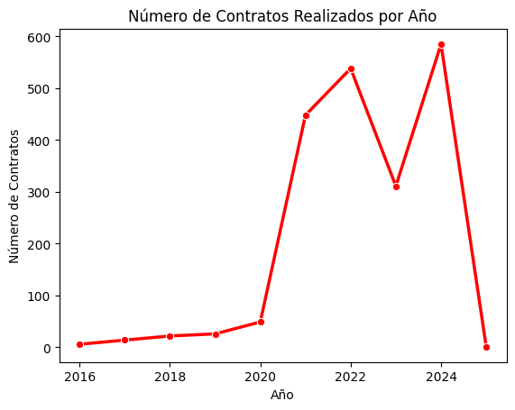

```python
#ver tabla de contratos por año
display(secop['ANNO_PAA'].value_counts())
# Gráfico de línea para ver cuántos contratos se realizaron por año
contratos_por_anno = secop.groupby('ANNO_PAA').size().reset_index(name='cantidad_contratos')
sns.lineplot(x='ANNO_PAA', y='cantidad_contratos', data=contratos_por_anno, color='red',marker='o', linewidth=2.5)

plt.xlabel('Año')
plt.ylabel('Número de Contratos')
plt.title('Número de Contratos Realizados por Año')

plt.show()
```

```python
#ver suma de presupuesto por año
secop.groupby('ANNO_PAA')['PPTO_TOTAL'].sum()
```

```
ANNO_PAA
2016    1.829235e+12
2017    2.851170e+12
2018    1.703861e+12
2019    8.810886e+11
2020    3.150822e+12
2021    2.020776e+14
2022    2.261243e+14
2023    2.777594e+13
2024    8.108686e+13
2025    0.000000e+00
Name: PPTO_TOTAL, dtype: float64
```

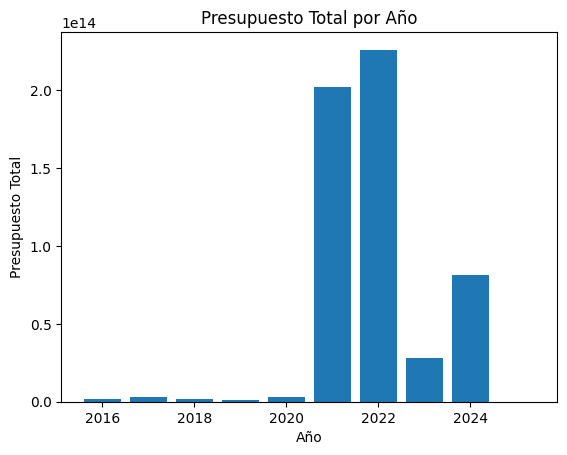

```python
# visualizar el presupuesto total por año
secop_agrupado = secop.groupby('ANNO_PAA')['PPTO_TOTAL'].sum()
annos = secop_agrupado.index.to_numpy()

# Create the barplot using the aggregated data
plt.bar(annos, secop_agrupado.values)
plt.xlabel('Año')
plt.ylabel('Presupuesto Total')
plt.title("Presupuesto Total por Año")
plt.show()
```

```python
secop[secop['ANNO_PAA'] == 2022]
```

|  | NIT_ENTIDAD | NOMBRE_ENTIDAD | ANNO_PAA | MISION_Y_VISION | PERSPECTIVA_ESTRATEGICA | PPTO_TOTAL | LIMITE_MENOR_CUANTIA | LIMITE_MINIMA_CUANTIA | FECHA_CARGUE | FECHA_ULTIMA_ACTUALIZACION | DEPARTAMENTO_PAA | MUNICIPIO_PAA |
| --- | --- | --- | --- | --- | --- | --- | --- | --- | --- | --- | --- | --- |
| 0 | 891855029.0 | CASANARE ESE HOSPITAL DE YOPAL ! | 2022 | MISIONEL HOSPITAL REGIONAL DE LA ORINOQUIA ES ... | EL HOSPITAL REGIONAL DE LA ORINOQUA ESE SE CON... | 1.268981e+11 | NaN | NaN | 2022-01-31 11:53:47.000000000 | 2021-12-31 00:00:00.000000000 | CASANARE | YOPAL |
| 1 | 900196642.0 | ANTIOQUIA INSTITUCIN EDUCATIVA DBORA ARANGO P... | 2022 | MISION LA INSTITUCIN EDUCATIVA DBORA ARANGO DE... | DIRECCIONAR LA INSTITUCIN PARA EL LOGRO DEL HO... | 8.402664e+07 | 0.0 | 20000000.0 | 2022-01-26 09:43:07.000000000 | 2021-12-01 00:00:00.000000000 | ANTIOQUIA | MEDELLIN |
| 4 | 900134298.0 | META CENTRO EDUCATIVO RURAL JOSE MARIA GUIOTH... | 2022 | MISIN | MEJORAMIENTO DE LA CALIDAD EDUCATIVA EN LA PRE... | 2.250000e+07 | 280000000.0 | 28000000.0 | 2022-01-28 07:06:52.000000000 | 2021-12-02 00:00:00.000000000 | META | CUMARAL |
| 5 | 826002718.0 | BOYAC ESE SALUD PAZ DE RO | 2022 | MISION LA ESE SALUD PAZ DE RIO ES UNA INSTIT... | LA EMPRESA SOCIAL DEL ESTADO SALUD PAZ DE RIO ... | 6.531199e+08 | NaN | NaN | 2022-01-31 06:12:36.000000000 | 2022-01-27 00:00:00.000000000 | BOYACA | PAZ DE RIO |
| 6 | 801004646.0 | QUINDO INSTITUCIN EDUCATIVA EL CAIMO ARMENIA | 2022 | MISION DESARROLLAR LOS PRINCIPIOS DE LA CONSTI... | LA INSTITUCIN EDUCATIVA EL CAIMO HA SIDO UNA D... | 7.013900e+07 | 280000000.0 | 28000000.0 | 2022-01-29 04:00:40.000000000 | 2022-01-29 00:00:00.000000000 | QUINDIO | ARMENIA |
| ... | ... | ... | ... | ... | ... | ... | ... | ... | ... | ... | ... | ... |
| 987 | 705288132.0 | FUNDACION EMPRESAS PUBLICAS DE MEDELLIN | 2022 | APORTAR AL DESARROLLO DE TERRITORIOS SOST... | GESTIN SOCIAL Y AMBIENTAL SERVICIOS PBLICOS D... | 1.377530e+10 | 999999999.0 | 38000000.0 | 2022-07-21 21:18:16.744562600 | 2022-12-14 20:38:54.756099700 | ANTIOQUIA | MEDELLIN |
| 992 | 718036205.0 | INSTITUCION EDUCATIVA LA PALMLLA | 2022 | MISIN LA INSTITUCIN EDUCATIVA LA PALMILLA TIEN... | LA INSTITUCIN EDUCATIVA LA PALMILLA TIENE COMO... | 4.498148e+07 | 664055700.0 | 66405570.0 | 2022-07-29 17:02:10.679730400 | 2022-12-19 16:01:40.751828900 | RISARALDA | PEREIRA |
| 997 | 709879217.0 | CONTRALORIA DISTRITAL DE BUENAVENTURA | 2022 | EJERCER EFICIENTEMENTE LA VIGILANCIA DE LA GES... | EL PLAN ANUAL DE ADQUISICIONES ES UN DOCUMENTO... | 8.998020e+08 | 280000000.0 | 28000000.0 | 2022-02-08 22:14:35.282438700 | 2023-08-17 22:50:41.294767000 | VALLE DEL CAUCA | BUENAVENTURA |
| 998 | 718687114.0 | INSTITUCION EDUCATIVA LICEO MIGUEL ANTONIO CARO | 2022 | NO DEFINIDO | NO DEFINIDO | 3.190250e+07 | 280000000.0 | 28000000.0 | 2022-09-29 14:58:23.404446400 | 2022-12-05 00:55:13.012865700 | CORDOBA | MONTERIA |
| 999 | 718933161.0 | INSTITUCION EDUCATIVA DON QUIJOTE | 2022 | MISIN LA INSTITUCIN EDUCATIVA DON QUIJOTE DEL ... | EL PRINCIPAL OBJETIVO DEL PLAN ANUAL DE ADQUIS... | 6.480000e+07 | 285000000.0 | 28500000.0 | 2022-12-30 14:54:06.509934200 | 2024-08-09 19:40:53.000000000 | CAQUETA | SAN JOSE DEL FRAGUA |

538 rows × 12 columns

|  | NIT_ENTIDAD | NOMBRE_ENTIDAD | ANNO_PAA | MISION_Y_VISION | PERSPECTIVA_ESTRATEGICA | PPTO_TOTAL | LIMITE_MENOR_CUANTIA | LIMITE_MINIMA_CUANTIA | FECHA_CARGUE | FECHA_ULTIMA_ACTUALIZACION | DEPARTAMENTO_PAA | MUNICIPIO_PAA |
| --- | --- | --- | --- | --- | --- | --- | --- | --- | --- | --- | --- | --- |
| 0 | 891855029.0 | CASANARE ESE HOSPITAL DE YOPAL ! | 2022 | MISIONEL HOSPITAL REGIONAL DE LA ORINOQUIA ES ... | EL HOSPITAL REGIONAL DE LA ORINOQUA ESE SE CON... | 1.268981e+11 | NaN | NaN | 2022-01-31 11:53:47.000000000 | 2021-12-31 00:00:00.000000000 | CASANARE | YOPAL |
| 1 | 900196642.0 | ANTIOQUIA INSTITUCIN EDUCATIVA DBORA ARANGO P... | 2022 | MISION LA INSTITUCIN EDUCATIVA DBORA ARANGO DE... | DIRECCIONAR LA INSTITUCIN PARA EL LOGRO DEL HO... | 8.402664e+07 | 0.0 | 20000000.0 | 2022-01-26 09:43:07.000000000 | 2021-12-01 00:00:00.000000000 | ANTIOQUIA | MEDELLIN |
| 4 | 900134298.0 | META CENTRO EDUCATIVO RURAL JOSE MARIA GUIOTH... | 2022 | MISIN | MEJORAMIENTO DE LA CALIDAD EDUCATIVA EN LA PRE... | 2.250000e+07 | 280000000.0 | 28000000.0 | 2022-01-28 07:06:52.000000000 | 2021-12-02 00:00:00.000000000 | META | CUMARAL |
| 5 | 826002718.0 | BOYAC ESE SALUD PAZ DE RO | 2022 | MISION LA ESE SALUD PAZ DE RIO ES UNA INSTIT... | LA EMPRESA SOCIAL DEL ESTADO SALUD PAZ DE RIO ... | 6.531199e+08 | NaN | NaN | 2022-01-31 06:12:36.000000000 | 2022-01-27 00:00:00.000000000 | BOYACA | PAZ DE RIO |
| 6 | 801004646.0 | QUINDO INSTITUCIN EDUCATIVA EL CAIMO ARMENIA | 2022 | MISION DESARROLLAR LOS PRINCIPIOS DE LA CONSTI... | LA INSTITUCIN EDUCATIVA EL CAIMO HA SIDO UNA D... | 7.013900e+07 | 280000000.0 | 28000000.0 | 2022-01-29 04:00:40.000000000 | 2022-01-29 00:00:00.000000000 | QUINDIO | ARMENIA |
| ... | ... | ... | ... | ... | ... | ... | ... | ... | ... | ... | ... | ... |
| 987 | 705288132.0 | FUNDACION EMPRESAS PUBLICAS DE MEDELLIN | 2022 | APORTAR AL DESARROLLO DE TERRITORIOS SOST... | GESTIN SOCIAL Y AMBIENTAL SERVICIOS PBLICOS D... | 1.377530e+10 | 999999999.0 | 38000000.0 | 2022-07-21 21:18:16.744562600 | 2022-12-14 20:38:54.756099700 | ANTIOQUIA | MEDELLIN |
| 992 | 718036205.0 | INSTITUCION EDUCATIVA LA PALMLLA | 2022 | MISIN LA INSTITUCIN EDUCATIVA LA PALMILLA TIEN... | LA INSTITUCIN EDUCATIVA LA PALMILLA TIENE COMO... | 4.498148e+07 | 664055700.0 | 66405570.0 | 2022-07-29 17:02:10.679730400 | 2022-12-19 16:01:40.751828900 | RISARALDA | PEREIRA |
| 997 | 709879217.0 | CONTRALORIA DISTRITAL DE BUENAVENTURA | 2022 | EJERCER EFICIENTEMENTE LA VIGILANCIA DE LA GES... | EL PLAN ANUAL DE ADQUISICIONES ES UN DOCUMENTO... | 8.998020e+08 | 280000000.0 | 28000000.0 | 2022-02-08 22:14:35.282438700 | 2023-08-17 22:50:41.294767000 | VALLE DEL CAUCA | BUENAVENTURA |
| 998 | 718687114.0 | INSTITUCION EDUCATIVA LICEO MIGUEL ANTONIO CARO | 2022 | NO DEFINIDO | NO DEFINIDO | 3.190250e+07 | 280000000.0 | 28000000.0 | 2022-09-29 14:58:23.404446400 | 2022-12-05 00:55:13.012865700 | CORDOBA | MONTERIA |
| 999 | 718933161.0 | INSTITUCION EDUCATIVA DON QUIJOTE | 2022 | MISIN LA INSTITUCIN EDUCATIVA DON QUIJOTE DEL ... | EL PRINCIPAL OBJETIVO DEL PLAN ANUAL DE ADQUIS... | 6.480000e+07 | 285000000.0 | 28500000.0 | 2022-12-30 14:54:06.509934200 | 2024-08-09 19:40:53.000000000 | CAQUETA | SAN JOSE DEL FRAGUA |

538 rows × 12 columns

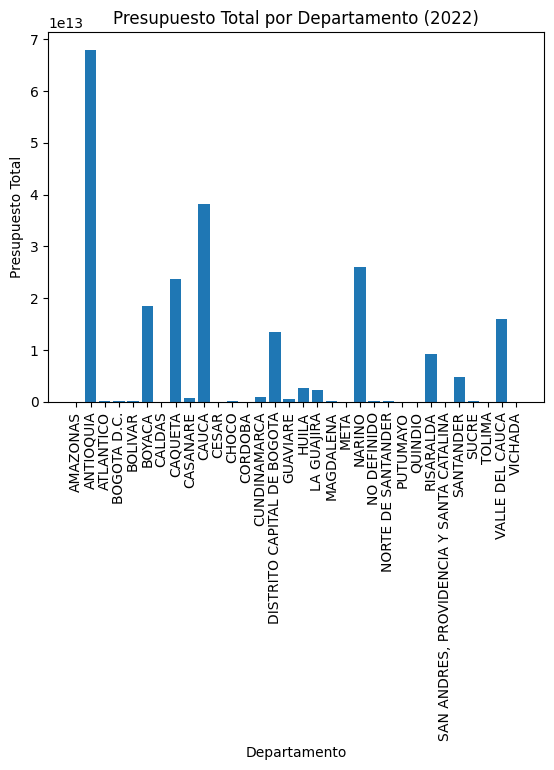

```python
#ver gráfico de barras de presupuesto por departamento para el 2022
secop_2022 = secop[secop['ANNO_PAA'] == 2022]
secop_2022_agrupado = secop_2022.groupby('DEPARTAMENTO_PAA')['PPTO_TOTAL'].sum()
departamentos = secop_2022_agrupado.index.to_numpy()
display(secop_2022)
# Crear el gráfico de barras
plt.bar(departamentos,secop_2022_agrupado.values)
plt.xlabel('Departamento')
plt.xticks(rotation=90)
plt.ylabel('Presupuesto Total')
plt.title("Presupuesto Total por Departamento (2022)")
plt.show()
```

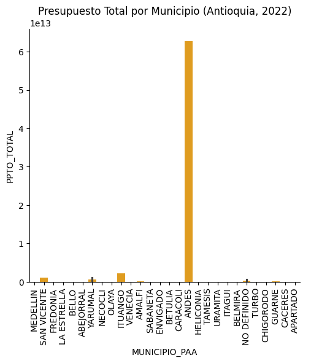

```python
#grafico de barras de presupuesto para 2022 en antioquia por municipios
secop_ant_2022 = secop_2022[secop_2022['DEPARTAMENTO_PAA'] == 'ANTIOQUIA']
sns.catplot(x="MUNICIPIO_PAA", y="PPTO_TOTAL", kind="bar", data=secop_ant_2022, color="orange")
plt.title("Presupuesto Total por Municipio (Antioquia, 2022)")
plt.xticks(rotation=90)
plt.show()
```

[figure not shown]

Created in Deepnote